# California College Demographics

Name: Vinh Ton

This notebook sets out to document the demographic differences between the California Community College (CCC), the California State University (CSU), and the University of California (UC) systems, particularly when it comes to gender, ethnicity, and age, and to see how these differences have changed from 2010 and 2015 to 2021. Unfortunately, the UC did not provide age demographics, so we will only focus on gender and ethnicity for the UC system.

I chose this topic to document the changing demographics of the different California college systems, especially as overall demographics have changed, and to see what differences there may be among the different systems.

The input data is all data provided through the official CCC, CSU, and UC sources:

CCC: https://datamart.cccco.edu/students/Student_Term_Annual_Count.aspx

CSU: https://tableau.calstate.edu/views/SelfEnrollmentDashboard/EnrollmentSummary?iframeSizedToWindow=true&%3Aembed=y&%3AshowAppBanner=false&%3Adisplay_count=no&%3AshowVizHome=no

UC: https://www.universityofcalifornia.edu/about-us/information-center/fall-enrollment-glance

CCC files were downloaded as CSV files, CSU and UC files were more easily read in as .xlsx files.

As this is only a data analysis notebook, our main modules will be Pandas, Numpy, and matplotlib.

```python
#import necessary tools for data analysis
import pandas as pd
import numpy as np
import matplotlib.pyplot as plt
%matplotlib inline
plt.style.use('seaborn-whitegrid')
```

1. Read data from the various xlsx and .csv files into dataframes.

The CCC data is already in one spreadsheet, so we can just read it in directly.

```python
commDF = pd.read_csv("CCdata.csv")
print("Rows, columns of CCC")
print(commDF.shape)
commDF.head()
```

```
Rows, columns of CCC
(271, 10)
```

|  | Unnamed: 0 | Unnamed: 1 | Unnamed: 2 | Unnamed: 3 | Fall 2010 | Fall 2010.1 | Fall 2015 | Fall 2015.1 | Fall 2021 | Fall 2021.1 |
| --- | --- | --- | --- | --- | --- | --- | --- | --- | --- | --- |
| 0 | State Name | Gender | Age Group | Ethnicity | Student Count | Student Count (%) | Student Count | Student Count (%) | Student Count | Student Count (%) |
| 1 | State of California | Female | 19 or Less | African-American | 13,183 | 5.80 % | 10,084 | 4.70 % | 8,924 | 3.87 % |
| 2 | State of California | Female | 19 or Less | American Indian/Alaskan Native | 948 | 0.42 % | 760 | 0.35 % | 586 | 0.25 % |
| 3 | State of California | Female | 19 or Less | Asian | 20,993 | 9.23 % | 19,083 | 8.90 % | 22,039 | 9.55 % |
| 4 | State of California | Female | 19 or Less | Filipino | 6,869 | 3.02 % | 6,146 | 2.87 % | 6,162 | 2.67 % |

The CSU data is broken up into years (2010, 2015, 2021), as well as separate demographics (Age, Ethnicity, Female). Each demographic will get its own dataframe.

```python
csuEthDF = pd.read_excel("CSU2010Ethnicity.xlsx")
csuEthDF = csuEthDF.append(pd.DataFrame(pd.read_excel("CSU2015Ethnicity.xlsx")), ignore_index=True)
csuEthDF = csuEthDF.append(pd.DataFrame(pd.read_excel("CSU2021Ethnicity.xlsx")), ignore_index=True)
print("Rows, Columns of CSU ethnicity")
print(csuEthDF.shape)
csuEthDF.head()
```

```
Rows, Columns of CSU ethnicity
(27, 6)
```

|  | Unnamed: 0 | Unnamed: 1 | Unnamed: 2 | N (copy 2) | Number of Records | Year Select |
| --- | --- | --- | --- | --- | --- | --- |
| 0 | White | 34% | Largest Group | 138992 | 138992 | 2010 |
| 1 | Hispanic\Latino | 27% | Other | 112572 | 112572 | 2010 |
| 2 | Asian | 16% | Other | 66582 | 66582 | 2010 |
| 3 | Race and Ethnicity Unknown | 9% | Other | 38201 | 38201 | 2010 |
| 4 | Black \| African American | 5% | Other | 21330 | 21330 | 2010 |

```python
csuAgeDF = pd.read_excel("CSU2010Age.xlsx")
csuAgeDF = csuAgeDF.append(pd.DataFrame(pd.read_excel("CSU2015Age.xlsx")), ignore_index=True)
csuAgeDF = csuAgeDF.append(pd.DataFrame(pd.read_excel("CSU2021Age.xlsx")), ignore_index=True)
print("Rows, Columns of CSU Age")
print(csuAgeDF.shape)
csuAgeDF.head()
```

```
Rows, Columns of CSU Age
(30, 7)
```

|  | Unnamed: 0 | Unnamed: 1 | Unnamed: 2 | % of Total Number of Records along erssp ipeds age Name | N (copy 2) | Number of Records | Year Select |
| --- | --- | --- | --- | --- | --- | --- | --- |
| 0 | Under 18 | 0% | Other | 0.003800 | 1567 | 1567 | 2010 |
| 1 | 18-19 | 21% | Other | 0.205431 | 84714 | 84714 | 2010 |
| 2 | 20-21 | 23% | Other | 0.226793 | 93523 | 93523 | 2010 |
| 3 | 22-24 | 27% | Largest Group | 0.268064 | 110542 | 110542 | 2010 |
| 4 | 25-29 | 16% | Other | 0.160615 | 66233 | 66233 | 2010 |

```python
csuGenDF = pd.read_excel("CSU2010Gender.xlsx")
csuGenDF = csuGenDF.append(pd.DataFrame(pd.read_excel("CSU2015Gender.xlsx")), ignore_index=True)
csuGenDF = csuGenDF.append(pd.DataFrame(pd.read_excel("CSU2021Gender.xlsx")), ignore_index=True)
print("Rows, Columns of CSU Gender")
print(csuGenDF.shape)
csuGenDF.head()
```

```
Rows, Columns of CSU Gender
(6, 6)
```

|  | Unnamed: 0 | Unnamed: 1 | Unnamed: 2 | N (copy 2) | Number of Records | Year Select |
| --- | --- | --- | --- | --- | --- | --- |
| 0 | Female | 57% | Largest Group | 236819 | 236819 | 2010 |
| 1 | Male | 43% | Other | 175553 | 175553 | 2010 |
| 2 | Female | 56% | Largest Group | 266091 | 266091 | 2015 |
| 3 | Male | 44% | Other | 208480 | 208480 | 2015 |
| 4 | Female | 58% | Largest Group | 275203 | 275203 | 2021 |

And the UC data comes in two files, one for ethnicity and one for gender. To keep the data organized, we'll keep them as separate dataframes.

```python
ucDFEth = pd.read_excel("UCEthnicity.xlsx")
print("Rows, columns of UC Ethnicity")
print(ucDFEth.shape)
ucDFEth.head()
```

```
Rows, columns of UC Ethnicity
(37, 5)
```

|  | Student level | Categories | 2010 | 2015 | 2021 |
| --- | --- | --- | --- | --- | --- |
| 0 | Undergraduate | African American | 6477 | 7410.0 | 9886.0 |
| 1 | NaN | American Indian | 1157 | 1196.0 | 1025.0 |
| 2 | NaN | Hispanic/Latino(a) | 31843 | 44657.0 | 57944.0 |
| 3 | NaN | Pacific Islander | 517 | 527.0 | 575.0 |
| 4 | NaN | Asian | 67543 | 69717.0 | 79999.0 |

```python
ucDFGen = pd.read_excel("UCGender.xlsx")
print("Rows, columns of UC Gender")
print(ucDFGen.shape)
ucDFGen.head()
```

```
Rows, columns of UC Gender
(29, 5)
```

|  | Student level | Categories | 2010 | 2015 | 2021 |
| --- | --- | --- | --- | --- | --- |
| 0 | Undergraduate | Female | 95146.0 | 106033.0 | 124738.0 |
| 1 | NaN | Trans Female/Trans Woman ... | NaN | NaN | 208.0 |
| 2 | NaN | Male | 83800.0 | 92459.0 | 101812.0 |
| 3 | NaN | Trans Male/Trans Man ... | NaN | NaN | 362.0 |
| 4 | NaN | Genderqueer or Nonbinary Gender ... | NaN | NaN | 1552.0 |

2) Now, we have to go through each set of dataframes and make sure we only have the data we need.

2a. For CCC, the column names should be the first row. However, the last six columns are for different years. We can safely drop the first row, and manually rename the columns.

```python
commDF.columns = ['state', 'gender', 'age', 'ethnicity', "2010Count", "2010Percent", "2015Count", "2015Percent", "2021Count", "2021Percent"]
commDF.head()
```

|  | state | gender | age | ethnicity | 2010Count | 2010Percent | 2015Count | 2015Percent | 2021Count | 2021Percent |
| --- | --- | --- | --- | --- | --- | --- | --- | --- | --- | --- |
| 0 | State Name | Gender | Age Group | Ethnicity | Student Count | Student Count (%) | Student Count | Student Count (%) | Student Count | Student Count (%) |
| 1 | State of California | Female | 19 or Less | African-American | 13,183 | 5.80 % | 10,084 | 4.70 % | 8,924 | 3.87 % |
| 2 | State of California | Female | 19 or Less | American Indian/Alaskan Native | 948 | 0.42 % | 760 | 0.35 % | 586 | 0.25 % |
| 3 | State of California | Female | 19 or Less | Asian | 20,993 | 9.23 % | 19,083 | 8.90 % | 22,039 | 9.55 % |
| 4 | State of California | Female | 19 or Less | Filipino | 6,869 | 3.02 % | 6,146 | 2.87 % | 6,162 | 2.67 % |

We can now drop the first row since we now have our column labels.

```python
commDF = commDF.drop(0)
commDF.head()
```

|  | state | gender | age | ethnicity | 2010Count | 2010Percent | 2015Count | 2015Percent | 2021Count | 2021Percent |
| --- | --- | --- | --- | --- | --- | --- | --- | --- | --- | --- |
| 1 | State of California | Female | 19 or Less | African-American | 13,183 | 5.80 % | 10,084 | 4.70 % | 8,924 | 3.87 % |
| 2 | State of California | Female | 19 or Less | American Indian/Alaskan Native | 948 | 0.42 % | 760 | 0.35 % | 586 | 0.25 % |
| 3 | State of California | Female | 19 or Less | Asian | 20,993 | 9.23 % | 19,083 | 8.90 % | 22,039 | 9.55 % |
| 4 | State of California | Female | 19 or Less | Filipino | 6,869 | 3.02 % | 6,146 | 2.87 % | 6,162 | 2.67 % |
| 5 | State of California | Female | 19 or Less | Hispanic | 96,686 | 42.52 % | 112,864 | 52.62 % | 124,285 | 53.86 % |

Let's also make sure our first three columns have differing values, and remove the columns that give no extra information.

```python
for col in commDF.columns[:3]:
    print("Checking uniqueness in", col)
    print(commDF[col].unique())
```

```
Checking uniqueness in state
['State of California']
Checking uniqueness in gender
['Female' 'Male' 'Non-Binary' 'Unknown']
Checking uniqueness in age
['19 or Less' '20 to 24' '25 to 29' '30 to 34' '35 to 39' '40 to 49'
 '50 +' 'Unknown']
```

```python
commDF.drop(columns="state", inplace=True)
commDF.head()
```

|  | gender | age | ethnicity | 2010Count | 2010Percent | 2015Count | 2015Percent | 2021Count | 2021Percent |
| --- | --- | --- | --- | --- | --- | --- | --- | --- | --- |
| 1 | Female | 19 or Less | African-American | 13,183 | 5.80 % | 10,084 | 4.70 % | 8,924 | 3.87 % |
| 2 | Female | 19 or Less | American Indian/Alaskan Native | 948 | 0.42 % | 760 | 0.35 % | 586 | 0.25 % |
| 3 | Female | 19 or Less | Asian | 20,993 | 9.23 % | 19,083 | 8.90 % | 22,039 | 9.55 % |
| 4 | Female | 19 or Less | Filipino | 6,869 | 3.02 % | 6,146 | 2.87 % | 6,162 | 2.67 % |
| 5 | Female | 19 or Less | Hispanic | 96,686 | 42.52 % | 112,864 | 52.62 % | 124,285 | 53.86 % |

We don't need the Percentage columns since those can be derived from the count columns.

```python
commDF.drop(columns=["2010Percent", "2015Percent", "2021Percent"], inplace=True)
commDF.head()
```

|  | gender | age | ethnicity | 2010Count | 2015Count | 2021Count |
| --- | --- | --- | --- | --- | --- | --- |
| 1 | Female | 19 or Less | African-American | 13,183 | 10,084 | 8,924 |
| 2 | Female | 19 or Less | American Indian/Alaskan Native | 948 | 760 | 586 |
| 3 | Female | 19 or Less | Asian | 20,993 | 19,083 | 22,039 |
| 4 | Female | 19 or Less | Filipino | 6,869 | 6,146 | 6,162 |
| 5 | Female | 19 or Less | Hispanic | 96,686 | 112,864 | 124,285 |

Let's check for NaNs. If there are any, we should replace them with 0 to make it easier to work with.

```python
print("CCC NaN?")
print(commDF.isna().sum())

#Since there are NaNs, we just replace them with 0.
commDF = commDF.fillna(0)
```

```
CCC NaN?
gender        0
age           0
ethnicity     0
2010Count    58
2015Count    61
2021Count     8
dtype: int64
```

Finally, the counts are strings, not integers. Let's remove the comma from each number, and then convert them into type int.

```python
commDF.replace(",","", regex=True, inplace=True)
commDF = commDF.astype({"2010Count": 'int', "2015Count": 'int', "2021Count": 'int'})
```

Let's check what our dataframe looks like now that we've filtered it.

```python
print("Rows, columns of commDF")
print(commDF.shape)
commDF.head()
```

```
Rows, columns of commDF
(270, 6)
```

|  | gender | age | ethnicity | 2010Count | 2015Count | 2021Count |
| --- | --- | --- | --- | --- | --- | --- |
| 1 | Female | 19 or Less | African-American | 13183 | 10084 | 8924 |
| 2 | Female | 19 or Less | American Indian/Alaskan Native | 948 | 760 | 586 |
| 3 | Female | 19 or Less | Asian | 20993 | 19083 | 22039 |
| 4 | Female | 19 or Less | Filipino | 6869 | 6146 | 6162 |
| 5 | Female | 19 or Less | Hispanic | 96686 | 112864 | 124285 |

Additionally, let's break this dataframe into different demographic dataframe to be consistent with how we have our other data labelled.

```python
commEth = commDF.drop(columns=["gender", "age"])
commEth.head()
```

|  | ethnicity | 2010Count | 2015Count | 2021Count |
| --- | --- | --- | --- | --- |
| 1 | African-American | 13183 | 10084 | 8924 |
| 2 | American Indian/Alaskan Native | 948 | 760 | 586 |
| 3 | Asian | 20993 | 19083 | 22039 |
| 4 | Filipino | 6869 | 6146 | 6162 |
| 5 | Hispanic | 96686 | 112864 | 124285 |

```python
commGen = commDF.drop(columns=["age", "ethnicity"])
commGen.head()
```

|  | gender | 2010Count | 2015Count | 2021Count |
| --- | --- | --- | --- | --- |
| 1 | Female | 13183 | 10084 | 8924 |
| 2 | Female | 948 | 760 | 586 |
| 3 | Female | 20993 | 19083 | 22039 |
| 4 | Female | 6869 | 6146 | 6162 |
| 5 | Female | 96686 | 112864 | 124285 |

```python
commAge = commDF.drop(columns=["gender", "ethnicity"])
commAge.head()
```

|  | age | 2010Count | 2015Count | 2021Count |
| --- | --- | --- | --- | --- |
| 1 | 19 or Less | 13183 | 10084 | 8924 |
| 2 | 19 or Less | 948 | 760 | 586 |
| 3 | 19 or Less | 20993 | 19083 | 22039 |
| 4 | 19 or Less | 6869 | 6146 | 6162 |
| 5 | 19 or Less | 96686 | 112864 | 124285 |

2b) For CSUs, each dataframe has unlabelled columns. Let's correctly label these columns.

```python
csuAgeDF.columns = ["age", "percentage", "majority", "decimal", "N", "records", "year"]
csuAgeDF.head()
```

|  | age | percentage | majority | decimal | N | records | year |
| --- | --- | --- | --- | --- | --- | --- | --- |
| 0 | Under 18 | 0% | Other | 0.003800 | 1567 | 1567 | 2010 |
| 1 | 18-19 | 21% | Other | 0.205431 | 84714 | 84714 | 2010 |
| 2 | 20-21 | 23% | Other | 0.226793 | 93523 | 93523 | 2010 |
| 3 | 22-24 | 27% | Largest Group | 0.268064 | 110542 | 110542 | 2010 |
| 4 | 25-29 | 16% | Other | 0.160615 | 66233 | 66233 | 2010 |

```python
csuEthDF.columns = ["ethnicity", "percentage", "majority", "N", "records", "year"]
csuEthDF.head()
```

|  | ethnicity | percentage | majority | N | records | year |
| --- | --- | --- | --- | --- | --- | --- |
| 0 | White | 34% | Largest Group | 138992 | 138992 | 2010 |
| 1 | Hispanic\Latino | 27% | Other | 112572 | 112572 | 2010 |
| 2 | Asian | 16% | Other | 66582 | 66582 | 2010 |
| 3 | Race and Ethnicity Unknown | 9% | Other | 38201 | 38201 | 2010 |
| 4 | Black \| African American | 5% | Other | 21330 | 21330 | 2010 |

```python
csuGenDF.columns = ["gender", "percentage", "majority", "N", "records", "year"]
csuGenDF.head()
```

|  | gender | percentage | majority | N | records | year |
| --- | --- | --- | --- | --- | --- | --- |
| 0 | Female | 57% | Largest Group | 236819 | 236819 | 2010 |
| 1 | Male | 43% | Other | 175553 | 175553 | 2010 |
| 2 | Female | 56% | Largest Group | 266091 | 266091 | 2015 |
| 3 | Male | 44% | Other | 208480 | 208480 | 2015 |
| 4 | Female | 58% | Largest Group | 275203 | 275203 | 2021 |

In each dataframe, the majority category can be derived by seeing which category has the highest percentage, so its redundant. Additionally, N and records give the same information. We can remove N. We can also remove percentange and decimal, since they can both be derived from the cords and the sum of the records column for each year.

```python
csuAgeDF.drop(columns=["majority", "N", "decimal", "percentage"], inplace=True)
csuAgeDF.head()
```

|  | age | records | year |
| --- | --- | --- | --- |
| 0 | Under 18 | 1567 | 2010 |
| 1 | 18-19 | 84714 | 2010 |
| 2 | 20-21 | 93523 | 2010 |
| 3 | 22-24 | 110542 | 2010 |
| 4 | 25-29 | 66233 | 2010 |

```python
csuEthDF.drop(columns=["majority", "N", "percentage"], inplace=True)
csuEthDF.head()
```

|  | ethnicity | records | year |
| --- | --- | --- | --- |
| 0 | White | 138992 | 2010 |
| 1 | Hispanic\Latino | 112572 | 2010 |
| 2 | Asian | 66582 | 2010 |
| 3 | Race and Ethnicity Unknown | 38201 | 2010 |
| 4 | Black \| African American | 21330 | 2010 |

```python
csuGenDF.drop(columns=["majority", "N", "percentage"], inplace=True)
csuGenDF.head()
```

|  | gender | records | year |
| --- | --- | --- | --- |
| 0 | Female | 236819 | 2010 |
| 1 | Male | 175553 | 2010 |
| 2 | Female | 266091 | 2015 |
| 3 | Male | 208480 | 2015 |
| 4 | Female | 275203 | 2021 |

Let's also quickly check for NaNs.

```python
print("CSU Age NaN?")
print(csuAgeDF.isna().sum())

print("CSU Gender NaN?")
print(csuGenDF.isna().sum())

print("CSU Ethnicity NaN?")
print(csuEthDF.isna().sum())
```

```
CSU Age NaN?
age        0
records    0
year       0
dtype: int64
CSU Gender NaN?
gender     0
records    0
year       0
dtype: int64
CSU Ethnicity NaN?
ethnicity    0
records      0
year         0
dtype: int64
```

A lack of NaNs means we don't have to change anything here. Let's do one last check to see what our data frames look like after all the adjustments.

```python
print("Rows, columns of CSU Age")
print(csuAgeDF.shape)
csuAgeDF.head()
```

```
Rows, columns of CSU Age
(30, 3)
```

|  | age | records | year |
| --- | --- | --- | --- |
| 0 | Under 18 | 1567 | 2010 |
| 1 | 18-19 | 84714 | 2010 |
| 2 | 20-21 | 93523 | 2010 |
| 3 | 22-24 | 110542 | 2010 |
| 4 | 25-29 | 66233 | 2010 |

```python
print("Rows, columns of CSU Gender")
print(csuGenDF.shape)
csuGenDF.head()
```

```
Rows, columns of CSU Gender
(6, 3)
```

|  | gender | records | year |
| --- | --- | --- | --- |
| 0 | Female | 236819 | 2010 |
| 1 | Male | 175553 | 2010 |
| 2 | Female | 266091 | 2015 |
| 3 | Male | 208480 | 2015 |
| 4 | Female | 275203 | 2021 |

```python
print("Rows, columns of CSU Ethnicity")
print(csuEthDF.shape)
csuEthDF.head()
```

```
Rows, columns of CSU Ethnicity
(27, 3)
```

|  | ethnicity | records | year |
| --- | --- | --- | --- |
| 0 | White | 138992 | 2010 |
| 1 | Hispanic\Latino | 112572 | 2010 |
| 2 | Asian | 66582 | 2010 |
| 3 | Race and Ethnicity Unknown | 38201 | 2010 |
| 4 | Black \| African American | 21330 | 2010 |

2c) For the UC dataframes, we aren't interested in the student level. We can drop this column from both dataframes.

```python
ucDFEth.drop(columns=["Student level"], inplace=True)
ucDFEth.head()
```

|  | Categories | 2010 | 2015 | 2021 |
| --- | --- | --- | --- | --- |
| 0 | African American | 6477 | 7410.0 | 9886.0 |
| 1 | American Indian | 1157 | 1196.0 | 1025.0 |
| 2 | Hispanic/Latino(a) | 31843 | 44657.0 | 57944.0 |
| 3 | Pacific Islander | 517 | 527.0 | 575.0 |
| 4 | Asian | 67543 | 69717.0 | 79999.0 |

```python
ucDFGen.drop(columns=["Student level"], inplace=True)
ucDFGen.head()
```

|  | Categories | 2010 | 2015 | 2021 |
| --- | --- | --- | --- | --- |
| 0 | Female | 95146.0 | 106033.0 | 124738.0 |
| 1 | Trans Female/Trans Woman ... | NaN | NaN | 208.0 |
| 2 | Male | 83800.0 | 92459.0 | 101812.0 |
| 3 | Trans Male/Trans Man ... | NaN | NaN | 362.0 |
| 4 | Genderqueer or Nonbinary Gender ... | NaN | NaN | 1552.0 |

Let's also replace those NaNs with 0s so that later on so that we have all numeric data to work with.

```python
ucDFEth = ucDFEth.fillna(0)
print("Rows, columns of ucDFEth")
print(ucDFEth.shape)
ucDFEth.head()
```

```
Rows, columns of ucDFEth
(37, 4)
```

|  | Categories | 2010 | 2015 | 2021 |
| --- | --- | --- | --- | --- |
| 0 | African American | 6477 | 7410.0 | 9886.0 |
| 1 | American Indian | 1157 | 1196.0 | 1025.0 |
| 2 | Hispanic/Latino(a) | 31843 | 44657.0 | 57944.0 |
| 3 | Pacific Islander | 517 | 527.0 | 575.0 |
| 4 | Asian | 67543 | 69717.0 | 79999.0 |

```python
ucDFGen = ucDFGen.fillna(0)
print("Rows, columns of ucDFGen")
print(ucDFGen.shape)
ucDFGen.head()
```

```
Rows, columns of ucDFGen
(29, 4)
```

|  | Categories | 2010 | 2015 | 2021 |
| --- | --- | --- | --- | --- |
| 0 | Female | 95146.0 | 106033.0 | 124738.0 |
| 1 | Trans Female/Trans Woman ... | 0.0 | 0.0 | 208.0 |
| 2 | Male | 83800.0 | 92459.0 | 101812.0 |
| 3 | Trans Male/Trans Man ... | 0.0 | 0.0 | 362.0 |
| 4 | Genderqueer or Nonbinary Gender ... | 0.0 | 0.0 | 1552.0 |

3) Now that we have our data frames settled, we can finally start conducting our analysis. We will look at each demographic area first (ethnicity, gender, and age) and see how they change from 2010 to 2015 to 2021

3a) First, we start by graphing the ethnicity distribution in 2010 for each system.

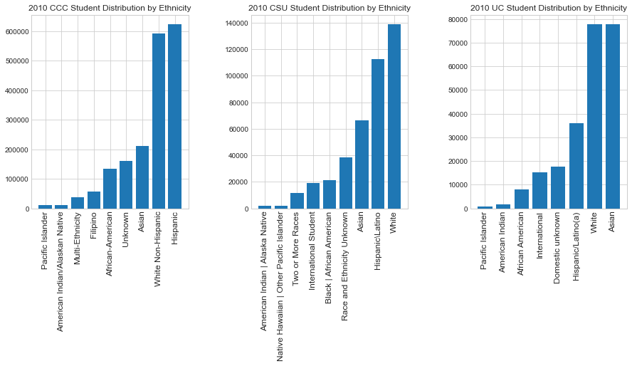

```python
figure = plt.figure(figsize=(15, 5))
plt.subplot(1, 3, 1)
plt.subplots_adjust(hspace=0.4, wspace=0.4)

cccEth = commEth.groupby("ethnicity").sum()
cccEth = cccEth.sort_values(by="2010Count")
plt.title("2010 CCC Student Distribution by Ethnicity", fontsize=12)
plt.bar(np.arange(len(cccEth.index)), cccEth["2010Count"], align="center")
plt.xticks(np.arange(len(cccEth.index)), cccEth.index.values, rotation=90, fontsize=12)


csuEth = csuEthDF[csuEthDF.year == 2010]
csuEth = csuEth.groupby("ethnicity").sum()
csuEth = csuEth.sort_values(by="records")
plt.subplot(1, 3, 2)
plt.title("2010 CSU Student Distribution by Ethnicity")
plt.bar(np.arange(len(csuEth.index)), csuEth["records"], align="center")
plt.xticks(np.arange(len(csuEth.index)), csuEth.index.values, rotation=90, fontsize=12)


ucEth = ucDFEth.groupby("Categories").sum()
ucEth = ucEth.sort_values(by="2010")
ucEth = ucEth.drop("Total")
plt.subplot(1, 3, 3)
plt.title("2010 UC Student Distribution by Ethnicity")
plt.bar(np.arange(len(ucEth.index)), ucEth["2010"], align="center")
plt.xticks(np.arange(len(ucEth.index)), ucEth.index.values, rotation=90, fontsize=12)
plt.show()
```

We can see that in 2010, the CCC system and CSU system were similar in that their students largely identified as White or Hispanic. The UC System, meanwhile, was mainly White and Asian. In all three cases, Hispanic/Latino, White, and Asian were still the top 3 ethnicities. Additionally, "American Indians" and "Pacific Islanders" were consistently the least-represented ethnicities in all three systems.

3b) Next, we graph the ethnicity distribution in 2015.

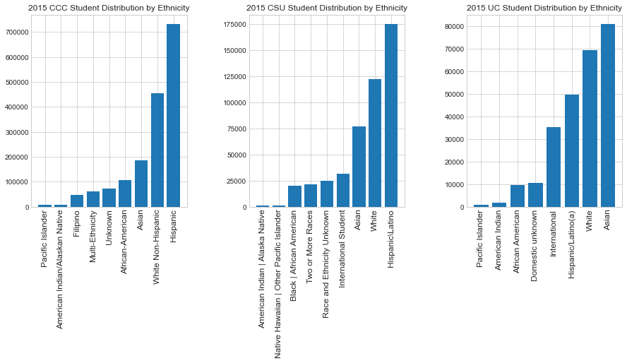

```python
figure = plt.figure(figsize=(15, 5))
plt.subplot(1, 3, 1)
plt.subplots_adjust(hspace=0.4, wspace=0.4)

cccEth = commEth.groupby("ethnicity").sum()
cccEth = cccEth.sort_values(by="2015Count")
plt.title("2015 CCC Student Distribution by Ethnicity", fontsize=12)
plt.bar(np.arange(len(cccEth.index)), cccEth["2015Count"], align="center")
plt.xticks(np.arange(len(cccEth.index)), cccEth.index.values, rotation=90, fontsize=12)


csuEth = csuEthDF[csuEthDF.year == 2015]
csuEth = csuEth.groupby("ethnicity").sum()
csuEth = csuEth.sort_values(by="records")
plt.subplot(1, 3, 2)
plt.title("2015 CSU Student Distribution by Ethnicity")
plt.bar(np.arange(len(csuEth.index)), csuEth["records"], align="center")
plt.xticks(np.arange(len(csuEth.index)), csuEth.index.values, rotation=90, fontsize=12)


ucEth = ucDFEth.groupby("Categories").sum()
ucEth = ucEth.sort_values(by="2015")
ucEth = ucEth.drop("Total")
plt.subplot(1, 3, 3)
plt.title("2015 UC Student Distribution by Ethnicity")
plt.bar(np.arange(len(ucEth.index)), ucEth["2015"], align="center")
plt.xticks(np.arange(len(ucEth.index)), ucEth.index.values, rotation=90, fontsize=12)
plt.show()
```

It's a similar breakdown in 2015. Asians, Hispanic/Latino, and White remain the top three demographics in CCC, CSUs, and UCs, and American Indians & Pacific Islanders remain the lowest. However, it is important to note that the 2015 UC distribution has significantly more Asians than Whites, which is a notable difference from 2010, in which Whites and Asians had similar counts.

Additionally, for the CSU system, the Hispanic/Latino count is considerably higher than the White count, compared to 2010 in which the amount of White students significantly outnumbered the Hispanic/Latino count. A similar pattern can be seen in the CCC distribution.

3c) Finally, we graph the ethnicity distribution in 2021.

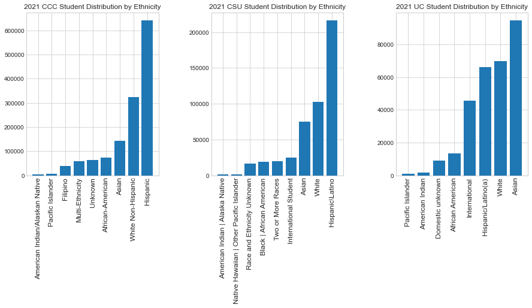

```python
figure = plt.figure(figsize=(15, 5))
plt.subplot(1, 3, 1)
plt.subplots_adjust(hspace=0.4, wspace=0.4)

cccEth = commEth.groupby("ethnicity").sum()
cccEth = cccEth.sort_values(by="2021Count")
plt.title("2021 CCC Student Distribution by Ethnicity", fontsize=12)
plt.bar(np.arange(len(cccEth.index)), cccEth["2021Count"], align="center")
plt.xticks(np.arange(len(cccEth.index)), cccEth.index.values, rotation=90, fontsize=12)


csuEth = csuEthDF[csuEthDF.year == 2021]
csuEth = csuEth.groupby("ethnicity").sum()
csuEth = csuEth.sort_values(by="records")
plt.subplot(1, 3, 2)
plt.title("2021 CSU Student Distribution by Ethnicity")
plt.bar(np.arange(len(csuEth.index)), csuEth["records"], align="center")
plt.xticks(np.arange(len(csuEth.index)), csuEth.index.values, rotation=90, fontsize=12)


ucEth = ucDFEth.groupby("Categories").sum()
ucEth = ucEth.sort_values(by="2021")
ucEth = ucEth.drop("Total")
plt.subplot(1, 3, 3)
plt.title("2021 UC Student Distribution by Ethnicity")
plt.bar(np.arange(len(ucEth.index)), ucEth["2021"], align="center")
plt.xticks(np.arange(len(ucEth.index)), ucEth.index.values, rotation=90, fontsize=12)
plt.show()
```

Patterns described in 2015 continue in 2021, with the growth of the Hispanic/Latino population in the CCC distribution and the diminishing of the White population. Asians, Whites, and Hispanics remain the top 3 ethnic groups, with Pacific Islanders and American Indians continuing to have the lowest enrollment.

However, in the UC system, there has been a significant increase in the Hispanic/Latino enrollment compared to previous years, with Hispanic/Latino enrollment now nearly matching the White distribution, whereas in 2010 and 2015, Hispanic/Latino population lagged behind both White and Asian enrollment.

4) Next, let's look at how gender distributions have changed from 2010 to 2015 to 2021 in each system.

4a) We begin by graphing the gender distribution in each year for each system.

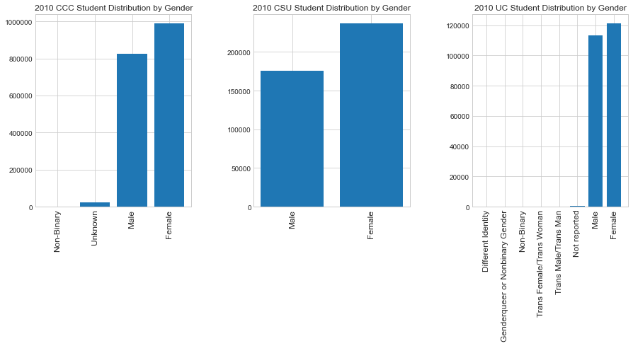

```python
#2010
figure = plt.figure(figsize=(15, 5))
plt.subplot(1, 3, 1)
plt.subplots_adjust(hspace=0.4, wspace=0.4)

cccGen = commGen.groupby("gender").sum()
cccGen = cccGen.sort_values(by="2010Count")
plt.ticklabel_format(style="plain")
plt.title("2010 CCC Student Distribution by Gender", fontsize=12)
plt.bar(np.arange(len(cccGen.index)), cccGen["2010Count"], align="center")

plt.xticks(np.arange(len(cccGen.index)), cccGen.index.values, rotation=90, fontsize=12)

csuGen = csuGenDF[csuGenDF.year == 2010]
csuGen = csuGen.groupby("gender").sum()
csuGen = csuGen.sort_values(by="records")
plt.subplot(1, 3, 2)
plt.title("2010 CSU Student Distribution by Gender")
plt.bar(np.arange(len(csuGen.index)), csuGen["records"], align="center")
plt.xticks(np.arange(len(csuGen.index)), csuGen.index.values, rotation=90, fontsize=12)

ucGen = ucDFGen.groupby("Categories").sum()
ucGen = ucGen.sort_values(by="2010")
ucGen.drop("Total", inplace=True)
plt.subplot(1, 3, 3)
plt.title("2010 UC Student Distribution by Gender")
plt.bar(np.arange(len(ucGen.index)), ucGen["2010"], align="center")
plt.xticks(np.arange(len(ucGen.index)), [word.strip() for word in ucGen.index.values], rotation=90, fontsize=12)
plt.show()
```

We can see that in all three systems, there were more female students than male students. Additionally, a small fraction of UC and CCC students were "unknown" or "non-reported," while the CSU demographics did not offer an "unknown" answer.

4b) Next, we graph 2015's gender distribution.

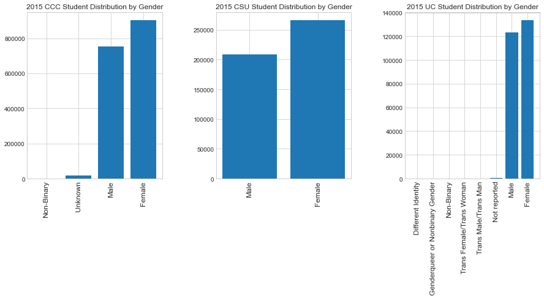

```python
#2015
figure = plt.figure(figsize=(15, 5))
plt.subplot(1, 3, 1)
plt.subplots_adjust(hspace=0.4, wspace=0.4)

cccGen = commGen.groupby("gender").sum()
cccGen = cccGen.sort_values(by="2015Count")
plt.ticklabel_format(style="plain")
plt.title("2015 CCC Student Distribution by Gender", fontsize=12)
plt.bar(np.arange(len(cccGen.index)), cccGen["2015Count"], align="center")

plt.xticks(np.arange(len(cccGen.index)), cccGen.index.values, rotation=90, fontsize=12)

csuGen = csuGenDF[csuGenDF.year == 2015]
csuGen = csuGen.groupby("gender").sum()
csuGen = csuGen.sort_values(by="records")
plt.subplot(1, 3, 2)
plt.title("2015 CSU Student Distribution by Gender")
plt.bar(np.arange(len(csuGen.index)), csuGen["records"], align="center")
plt.xticks(np.arange(len(csuGen.index)), csuGen.index.values, rotation=90, fontsize=12)

ucGen = ucDFGen.groupby("Categories").sum()
ucGen = ucGen.sort_values(by="2015")
ucGen.drop("Total", inplace=True)
plt.subplot(1, 3, 3)
plt.title("2015 UC Student Distribution by Gender")
plt.bar(np.arange(len(ucGen.index)), ucGen["2015"], align="center")
plt.xticks(np.arange(len(ucGen.index)), [word.strip() for word in ucGen.index.values], rotation=90, fontsize=12)
plt.show()
```

Not much change happens here from 2010 to 2015. There are still generally more female students enrolled compared to male students, and it is difficult to see if there is a significant proportion difference just from a graph.

Finally, we check for gender distribution in 2021.

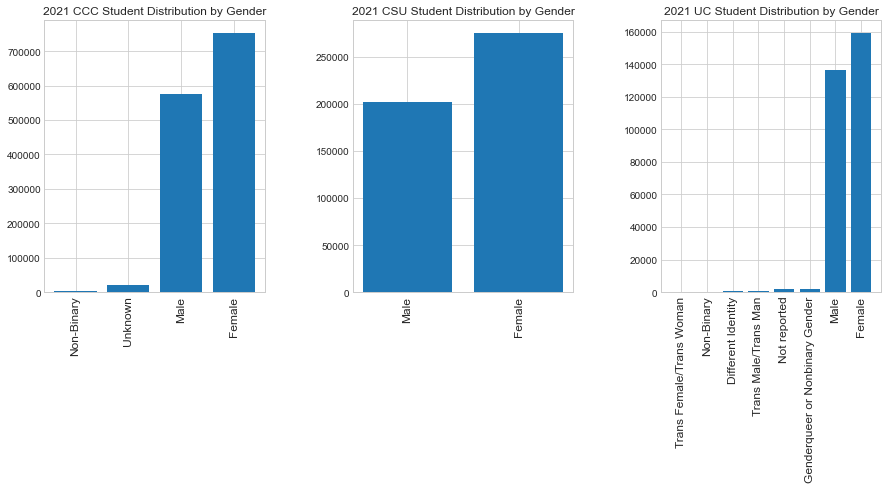

```python
figure = plt.figure(figsize=(15, 5))
plt.subplot(1, 3, 1)
plt.subplots_adjust(hspace=0.4, wspace=0.4)

cccGen = commGen.groupby("gender").sum()
cccGen = cccGen.sort_values(by="2021Count")
plt.ticklabel_format(style="plain")
plt.title("2021 CCC Student Distribution by Gender", fontsize=12)
plt.bar(np.arange(len(cccGen.index)), cccGen["2021Count"], align="center")

plt.xticks(np.arange(len(cccGen.index)), cccGen.index.values, rotation=90, fontsize=12)

csuGen = csuGenDF[csuGenDF.year == 2021]
csuGen = csuGen.groupby("gender").sum()
csuGen = csuGen.sort_values(by="records")
plt.subplot(1, 3, 2)
plt.title("2021 CSU Student Distribution by Gender")
plt.bar(np.arange(len(csuGen.index)), csuGen["records"], align="center")
plt.xticks(np.arange(len(csuGen.index)), csuGen.index.values, rotation=90, fontsize=12)

ucGen = ucDFGen.groupby("Categories").sum()
ucGen = ucGen.sort_values(by="2021")
ucGen.drop("Total", inplace=True)
plt.subplot(1, 3, 3)
plt.title("2021 UC Student Distribution by Gender")
plt.bar(np.arange(len(ucGen.index)), ucGen["2021"], align="center")
plt.xticks(np.arange(len(ucGen.index)), [word.strip() for word in ucGen.index.values], rotation=90, fontsize=12)
plt.show()
```

It is important to note that this is the first year that the UC system began offering gender options outside of the "Male/Female/Not Reported" category. Thus, it is important to note that there is now a small proportion of UC students who identify as genderqueer/nonbinary, a trans male, or as a different identity.

Overall, however, the patterns seem to be generally the same for each college system.

5) Finally, we look at the age demographics for each system. Again, the UC system did not offer this information, so we can only compare the CCC and CSU systems.

5a) 2010 Age distribution.

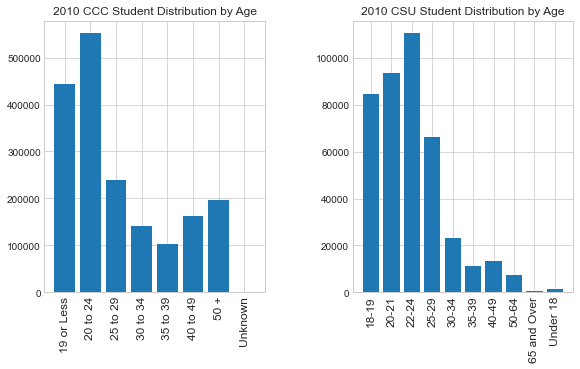

```python
figure = plt.figure(figsize=(15, 5))
plt.subplot(1, 3, 1)
plt.subplots_adjust(hspace=0.4, wspace=0.4)

cccAge = commAge.groupby("age").sum()
plt.title("2010 CCC Student Distribution by Age", fontsize=12)
plt.bar(np.arange(len(cccAge.index)), cccAge["2010Count"], align="center")
plt.xticks(np.arange(len(cccAge.index)), cccAge.index.values, rotation=90, fontsize=12)

csuAge = csuAgeDF[csuAgeDF.year == 2010]
csuAge = csuAge.groupby("age").sum()
plt.subplot(1, 3, 2)
plt.title("2010 CSU Student Distribution by Age")
plt.bar(np.arange(len(csuAge.index)), csuAge["records"], align="center")
plt.xticks(np.arange(len(csuAge.index)), csuAge.index.values, rotation=90, fontsize=12)
plt.show()
```

Both graphs show a heavy right-skew, meaning that generally, CCC and CSU students skewed younger. However, while the number of students in the CSU system generally decreases with age, it seems that after the age of 35-39, there is a significant peak in the 40-49 and 50+ age category of the CCC system, whereas those equivalent categores in the CSU system generally follow the downward trend.

5b) 2015 Age distribution.

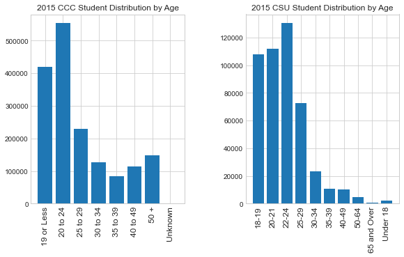

```python
figure = plt.figure(figsize=(15, 5))
plt.subplot(1, 3, 1)
plt.subplots_adjust(hspace=0.4, wspace=0.4)

cccAge = commAge.groupby("age").sum()
plt.title("2015 CCC Student Distribution by Age", fontsize=12)
plt.bar(np.arange(len(cccAge.index)), cccAge["2015Count"], align="center")
plt.xticks(np.arange(len(cccAge.index)), cccAge.index.values, rotation=90, fontsize=12)

csuAge = csuAgeDF[csuAgeDF.year == 2015]
csuAge = csuAge.groupby("age").sum()
plt.subplot(1, 3, 2)
plt.title("2015 CSU Student Distribution by Age")
plt.bar(np.arange(len(csuAge.index)), csuAge["records"], align="center")
plt.xticks(np.arange(len(csuAge.index)), csuAge.index.values, rotation=90, fontsize=12)
plt.show()
```

The patterns in 2015 seem to echo the patterns in 2010. The graphs even peak in the same areas.

5c) Now the 2021 Age distribution.

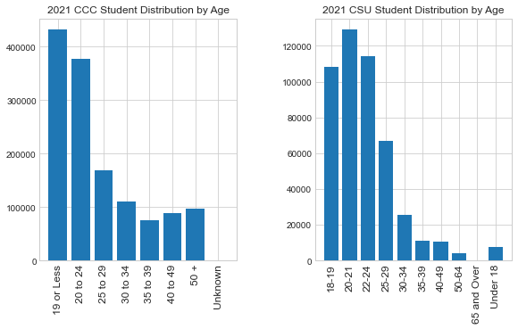

```python
figure = plt.figure(figsize=(15, 5))
plt.subplot(1, 3, 1)
plt.subplots_adjust(hspace=0.4, wspace=0.4)

cccAge = commAge.groupby("age").sum()
plt.title("2021 CCC Student Distribution by Age", fontsize=12)
plt.bar(np.arange(len(cccAge.index)), cccAge["2021Count"], align="center")
plt.xticks(np.arange(len(cccAge.index)), cccAge.index.values, rotation=90, fontsize=12)

csuAge = csuAgeDF[csuAgeDF.year == 2021]
csuAge = csuAge.groupby("age").sum()
plt.subplot(1, 3, 2)
plt.title("2021 CSU Student Distribution by Age")
plt.bar(np.arange(len(csuAge.index)), csuAge["records"], align="center")
plt.xticks(np.arange(len(csuAge.index)), csuAge.index.values, rotation=90, fontsize=12)
plt.show()
```

Overall, the patterns seem to be relatively the same from 2015. However, there are a few noticeable differences.

In the CCC system, for example, the peak of the graph now seems to be in the 19 or less category, as opposed to being in the 20 to 24 category, suggesting that CCC students in 2021 seem to generally be younger than in previous years.

Also, the CSU age distribution has a significant increase in the "Under 18" category, whereas it was much more limited in previous years. Again this suggests that by 2021, the CSU system has gained a number of younger students compared to previous years.

6) Now that we have a general idea for what patterns have emerged over the years, it is helpful to look at this data in terms of percentages so that we can compare more directly across systems and between years, especially since different systems and years may have drastically different totals of student enrollment. To do this, we first have to convert all the counts to percentages.

6a) Converting the CCC count data to percentages.

```python
#Ethnicity

commEthDF = commEth.groupby("ethnicity").sum()
for col in commEthDF:
    commEthDF[col] = (commEthDF[col]/sum(commEthDF[col]))*100

print("Rows, columns of commEthDF")
print(commEthDF.size)
commEthDF.head()
```

```
Rows, columns of commEthDF
27
```

| ethnicity | 2010Count | 2015Count | 2021Count |
| --- | --- | --- | --- |
| African-American | 7.338968 | 6.340063 | 5.409754 |
| American Indian/Alaskan Native | 0.604905 | 0.440689 | 0.324242 |
| Asian | 11.451886 | 11.107979 | 10.586966 |
| Filipino | 3.064525 | 2.804642 | 2.761791 |
| Hispanic | 34.002565 | 43.772796 | 47.494212 |

```python
#Age
commAgeDF = commAge.groupby("age").sum()
for col in commAgeDF:
    commAgeDF[col] = (commAgeDF[col]/sum(commAgeDF[col]))*100

print("Rows, columns of commAgeDF")
print(commAgeDF.size)
commAgeDF.head()
```

```
Rows, columns of commAgeDF
24
```

| age | 2010Count | 2015Count | 2021Count |
| --- | --- | --- | --- |
| 19 or Less | 24.157609 | 24.988296 | 31.937413 |
| 20 to 24 | 30.012969 | 33.034505 | 27.892643 |
| 25 to 29 | 12.986053 | 13.713715 | 12.513248 |
| 30 to 34 | 7.699517 | 7.557272 | 8.231050 |
| 35 to 39 | 5.579275 | 5.033285 | 5.540901 |

```python
#Gender
commGenDF = commGen.groupby("gender").sum()
for col in commGenDF:
    commGenDF[col] = (commGenDF[col]/sum(commGenDF[col]))*100

print("Rows, columns of commGenPercent")
print(commGenDF.size)
commGenDF.head()
```

```
Rows, columns of commGenPercent
12
```

| gender | 2010Count | 2015Count | 2021Count |
| --- | --- | --- | --- |
| Female | 53.792887 | 53.895556 | 55.666350 |
| Male | 44.921384 | 45.032341 | 42.616893 |
| Non-Binary | 0.000000 | 0.000000 | 0.239277 |
| Unknown | 1.285729 | 1.072103 | 1.477480 |

6b) Now we repeat this process for the CSU dataframes.

```python
#Ethnicity
csuEth2010 = csuEthDF[csuEthDF.year == 2010].groupby("ethnicity").sum()
csuEthPercent1 = (csuEth2010["records"]/sum(csuEth2010["records"]))*100

csuEth2015 = csuEthDF[csuEthDF.year == 2015].groupby("ethnicity").sum()
csuEthPercent2 = (csuEth2015["records"]/sum(csuEth2015["records"]))*100

csuEth2021 = csuEthDF[csuEthDF.year == 2021].groupby("ethnicity").sum()
csuEthPercent3 = (csuEth2021["records"]/sum(csuEth2021["records"]))*100

csuEthPercent = pd.concat([csuEthPercent1, csuEthPercent2, csuEthPercent3], axis=1)
csuEthPercent.columns = ["2010", "2015", "2021"]
print("Rows, columns of csuEthPercent")
print(csuEthPercent.shape)
csuEthPercent.head()
```

```
Rows, columns of csuEthPercent
(9, 3)
```

| ethnicity | 2010 | 2015 | 2021 |
| --- | --- | --- | --- |
| American Indian \| Alaska Native | 0.486211 | 0.253071 | 0.187657 |
| Asian | 16.146101 | 16.207480 | 15.739969 |
| Black \| African American | 5.172514 | 4.247204 | 3.994630 |
| Hispanic\Latino | 27.298653 | 36.940521 | 45.384174 |
| International Student | 4.612340 | 6.599434 | 5.238279 |

```python
#Age
csuAge2010 = csuAgeDF[csuAgeDF.year == 2010].groupby("age").sum()
csuAgePercent1 = (csuAge2010["records"]/sum(csuAge2010["records"]))*100

csuAge2015 = csuAgeDF[csuAgeDF.year == 2015].groupby("age").sum()
csuAgePercent2 = (csuAge2015["records"]/sum(csuAge2015["records"]))*100

csuAge2021 = csuAgeDF[csuAgeDF.year == 2021].groupby("age").sum()
csuAgePercent3 = (csuAge2021["records"]/sum(csuAge2021["records"]))*100

csuAgePercent = pd.concat([csuAgePercent1, csuAgePercent2, csuAgePercent3], axis=1)
csuAgePercent.columns = ["2010", "2015", "2021"]
print("Rows, columns of csuAgePercent")
print(csuAgePercent.shape)
csuAgePercent.head()
```

```
Rows, columns of csuAgePercent
(10, 3)
```

| age | 2010 | 2015 | 2021 |
| --- | --- | --- | --- |
| 18-19 | 20.543102 | 22.778889 | 22.662975 |
| 20-21 | 22.679280 | 23.573290 | 27.005693 |
| 22-24 | 26.806379 | 27.465648 | 23.913745 |
| 25-29 | 16.061469 | 15.349863 | 13.977540 |
| 30-34 | 5.640053 | 4.903797 | 5.322054 |

```python
#Gender
csuGen2010 = csuGenDF[csuGenDF.year == 2010].groupby("gender").sum()
csuGenPercent1 = (csuGen2010["records"]/sum(csuGen2010["records"]))*100

csuGen2015 = csuGenDF[csuGenDF.year == 2015].groupby("gender").sum()
csuGenPercent2 = (csuGen2015["records"]/sum(csuGen2015["records"]))*100

csuGen2021 = csuGenDF[csuGenDF.year == 2021].groupby("gender").sum()
csuGenPercent3 = (csuGen2021["records"]/sum(csuGen2021["records"]))*100

csuGenPercent = pd.concat([csuGenPercent1, csuGenPercent2, csuGenPercent3], axis=1)
csuGenPercent.columns = ["2010", "2015", "2021"]
print("Rows, columns of csuAgePercent")
print(csuGenPercent.shape)
csuGenPercent.head()
```

```
Rows, columns of csuAgePercent
(2, 3)
```

| gender | 2010 | 2015 | 2021 |
| --- | --- | --- | --- |
| Female | 57.428487 | 56.069798 | 57.63824 |
| Male | 42.571513 | 43.930202 | 42.36176 |

6c) Finally, we convert the UC data into percentages.

```python
#Ethnicity & gender can be done in the same for loop.
ucEth = ucDFEth.groupby("Categories").sum().drop("Total")
ucGen = ucDFGen.groupby("Categories").sum().drop("Total")
for col in ucEth:
    ucEth[col] = (ucEth[col]/sum(ucEth[col]))*100
    ucGen[col] = (ucGen[col]/sum(ucGen[col]))*100
ucEth.head()
```

| Categories | 2010 | 2015 | 2021 |
| --- | --- | --- | --- |
| African American | 3.407773 | 3.667291 | 4.460938 |
| American Indian | 0.656391 | 0.656080 | 0.495586 |
| Asian | 33.202112 | 31.451068 | 31.488154 |
| Domestic unknown | 7.482172 | 4.070883 | 2.972186 |
| Hispanic/Latino(a) | 15.351184 | 19.293577 | 21.972970 |

```python
#Gender
ucGen.head()
```

| Categories | 2010 | 2015 | 2021 |
| --- | --- | --- | --- |
| Different Identity | 0.000000 | 0.000000 | 0.118663 |
| Female | 51.656352 | 51.864556 | 52.881659 |
| Genderqueer or Nonbinary Gender | 0.000000 | 0.000000 | 0.682065 |
| Male | 48.216121 | 47.973850 | 45.372294 |
| Non-Binary | 0.000000 | 0.000000 | 0.108692 |

7) Now that we have all of our data in percentages, let's display them for ease of use.

7a) Percentages for ethnicity.

```python
print("CCC Ethnicity")
print(commEthDF)

print("CSU Ethnicity")
print(csuEthPercent)

print("UC Ethnicity")
print(ucEth)
```

```
CCC Ethnicity
                                2010Count  2015Count  2021Count
ethnicity
African-American                 7.338968   6.340063   5.409754
American Indian/Alaskan Native   0.604905   0.440689   0.324242
Asian                           11.451886  11.107979  10.586966
Filipino                         3.064525   2.804642   2.761791
Hispanic                        34.002565  43.772796  47.494212
Multi-Ethnicity                  2.037683   3.678794   4.313726
Pacific Islander                 0.592823   0.429761   0.402767
Unknown                          8.680643   4.308000   4.700581
White Non-Hispanic              32.226001  27.117276  24.005959
CSU Ethnicity
                                               2010       2015       2021
ethnicity
American Indian | Alaska Native            0.486211   0.253071   0.187657
Asian                                     16.146101  16.207480  15.739969
Black | African American                   5.172514   4.247204   3.994630
Hispanic\Latino                           27.298653  36.940521  45.384174
International Student                      4.612340   6.599434   5.238279
Native Hawaiian | Other Pacific Islander   0.503914   0.273932   0.318976
Race and Ethnicity Unknown                 9.263723   5.156868   3.401499
Two or More Races                          2.811054   4.554008   4.195273
White                                     33.705489  25.767483  21.539544
UC Ethnicity
                         2010       2015       2021
Categories
African American     3.407773   3.667291   4.460938
American Indian      0.656391   0.656080   0.495586
Asian               33.202112  31.451068  31.488154
Domestic unknown     7.482172   4.070883   2.972186
Hispanic/Latino(a)  15.351184  19.293577  21.972970
International        6.473488  13.654550  15.112546
Pacific Islander     0.281067   0.265695   0.274550
White               33.145813  26.940856  23.223070
```

7b) Percentages for gender.

```python
print("CCC Gender")
print(commGenDF)

print("CSU Gender")
print(csuGenPercent)

print("UC Gender")
print(ucGen)
```

```
CCC Gender
            2010Count  2015Count  2021Count
gender
Female      53.792887  53.895556  55.666350
Male        44.921384  45.032341  42.616893
Non-Binary   0.000000   0.000000   0.239277
Unknown      1.285729   1.072103   1.477480
CSU Gender
             2010       2015      2021
gender
Female  57.428487  56.069798  57.63824
Male    42.571513  43.930202  42.36176
UC Gender
                                                         2010       2015  \
Categories
Different Identity                                   0.000000   0.000000
Female                                              51.656352  51.864556
Genderqueer or Nonbinary Gender                      0.000000   0.000000
Male                                                48.216121  47.973850
Non-Binary                                           0.000000   0.000000
Not reported                                         0.127527   0.161595
Trans Female/Trans Woman                             0.000000   0.000000
Trans Male/Trans Man                                 0.000000   0.000000

                                                         2021
Categories
Different Identity                                   0.118663
Female                                              52.881659
Genderqueer or Nonbinary Gender                      0.682065
Male                                                45.372294
Non-Binary                                           0.108692
Not reported                                         0.603621
Trans Female/Trans Woman                             0.093069
Trans Male/Trans Man                                 0.139936
```

7c) Percentages for age.

```python
print("CCC Age")
print(commAgeDF)

print("CSU Age")
print(csuAgePercent)
```

```
CCC Age
            2010Count  2015Count  2021Count
age
19 or Less  24.157609  24.988296  31.937413
20 to 24    30.012969  33.034505  27.892643
25 to 29    12.986053  13.713715  12.513248
30 to 34     7.699517   7.557272   8.231050
35 to 39     5.579275   5.033285   5.540901
40 to 49     8.845489   6.831091   6.635005
50 +        10.669238   8.823266   7.238860
Unknown      0.049851   0.018571   0.010880
CSU Age
                  2010       2015       2021
age
18-19        20.543102  22.778889  22.662975
20-21        22.679280  23.573290  27.005693
22-24        26.806379  27.465648  23.913745
25-29        16.061469  15.349863  13.977540
30-34         5.640053   4.903797   5.322054
35-39         2.758432   2.234650   2.369174
40-49         3.237853   2.121074   2.170207
50-64         1.762486   1.038412   0.877340
65 and Over   0.130950   0.087026   0.081472
Under 18      0.379997   0.447351   1.619801
```

8) While the raw data is very helpful, it can also be useful to visualize it. Let's plot pie charts for each demographic group across the years.

8a) Plotting pie charts for 2010 demographic groups.

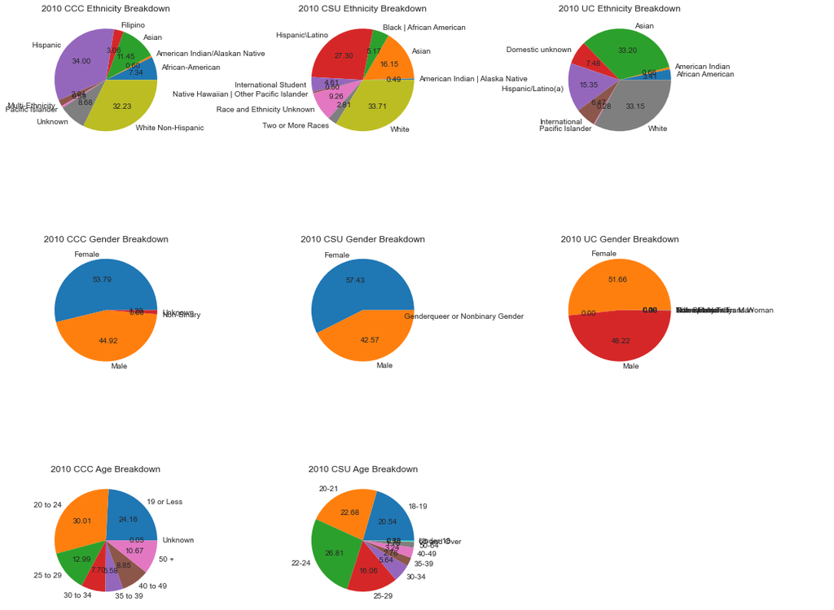

```python
figure = plt.figure(figsize=(15,15))
plt.subplots_adjust(hspace=0.4, wspace=1)

plt.subplot(3, 3, 1)
plt.title("2010 CCC Ethnicity Breakdown")
plt.pie(commEthDF["2010Count"], labels=commEthDF.index.values, autopct='%.2f')

plt.subplot(3, 3, 2)
plt.title("2010 CSU Ethnicity Breakdown")
plt.pie(csuEthPercent["2010"], labels=csuEthPercent.index.values, autopct='%.2f')

plt.subplot(3, 3, 3)
plt.title("2010 UC Ethnicity Breakdown")
plt.pie(ucEth["2010"], labels=ucEth.index.values, autopct='%.2f')

plt.subplot(3, 3, 4)
plt.title("2010 CCC Gender Breakdown")
plt.pie(commGenDF["2010Count"], labels=commGenDF.index.values, autopct='%.2f')

plt.subplot(3, 3, 5)
plt.title("2010 CSU Gender Breakdown")
plt.pie(csuGenPercent["2010"], labels=csuGenPercent.index.values, autopct='%.2f')

plt.subplot(3, 3, 6)
plt.title("2010 UC Gender Breakdown")
plt.pie(ucGen["2010"], labels=ucGen.index.values, autopct='%.2f')

plt.subplot(3, 3, 7)
plt.title("2010 CCC Age Breakdown")
plt.pie(commAgeDF["2010Count"], labels=commAgeDF.index.values, autopct='%.2f')

plt.subplot(3, 3, 8)
plt.title("2010 CSU Age Breakdown")
plt.pie(csuAgePercent["2010"], labels=csuAgePercent.index.values, autopct='%.2f')
plt.show()
```

8b) Plotting pie charts for 2015 demographic groups.

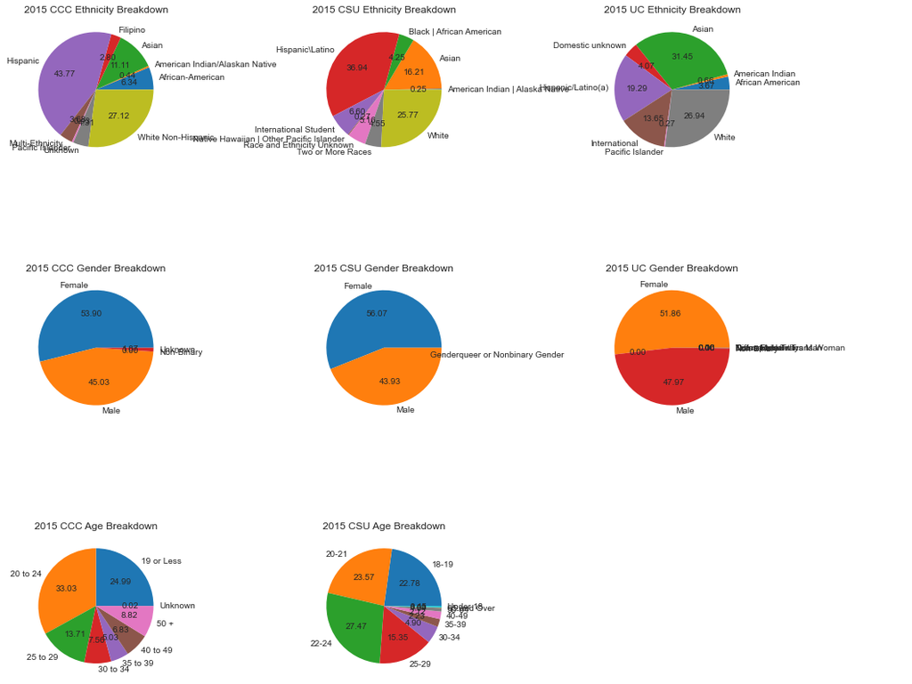

```python
figure = plt.figure(figsize=(15,15))
plt.subplots_adjust(hspace=0.4, wspace=1)

plt.subplot(3, 3, 1)
plt.title("2015 CCC Ethnicity Breakdown")
plt.pie(commEthDF["2015Count"], labels=commEthDF.index.values, autopct='%.2f')
plt.subplot(3, 3, 2)
plt.title("2015 CSU Ethnicity Breakdown")
plt.pie(csuEthPercent["2015"], labels=csuEthPercent.index.values, autopct='%.2f')
plt.subplot(3, 3, 3)
plt.title("2015 UC Ethnicity Breakdown")
plt.pie(ucEth["2015"], labels=ucEth.index.values, autopct='%.2f')

plt.subplot(3, 3, 4)
plt.title("2015 CCC Gender Breakdown")
plt.pie(commGenDF["2015Count"], labels=commGenDF.index.values, autopct='%.2f')
plt.subplot(3, 3, 5)
plt.title("2015 CSU Gender Breakdown")
plt.pie(csuGenPercent["2015"], labels=csuGenPercent.index.values, autopct='%.2f')
plt.subplot(3, 3, 6)
plt.title("2015 UC Gender Breakdown")
plt.pie(ucGen["2015"], labels=ucGen.index.values, autopct='%.2f')

plt.subplot(3, 3, 7)
plt.title("2015 CCC Age Breakdown")
plt.pie(commAgeDF["2015Count"], labels=commAgeDF.index.values, autopct='%.2f')
plt.subplot(3, 3, 8)
plt.title("2015 CSU Age Breakdown")
plt.pie(csuAgePercent["2015"], labels=csuAgePercent.index.values, autopct='%.2f')
plt.show()
```

8c) Plotting pie charts for 2021 demographic groups.

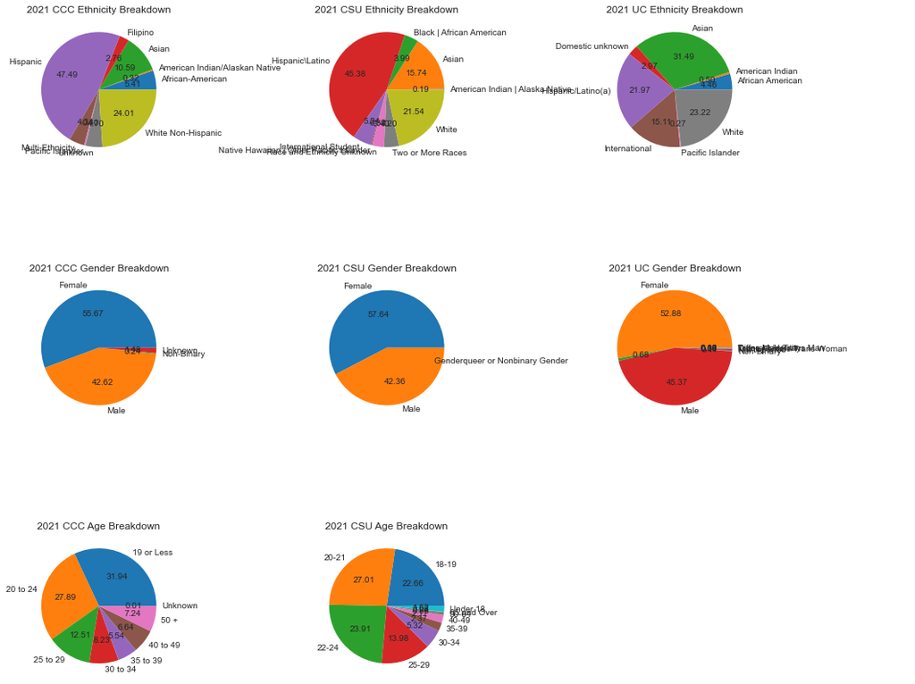

```python
figure = plt.figure(figsize=(15,15))
plt.subplots_adjust(hspace=0.4, wspace=1)

plt.subplot(3, 3, 1)
plt.title("2021 CCC Ethnicity Breakdown")
plt.pie(commEthDF["2021Count"], labels=commEthDF.index.values, autopct='%.2f')

plt.subplot(3, 3, 2)
plt.title("2021 CSU Ethnicity Breakdown")
plt.pie(csuEthPercent["2021"], labels=csuEthPercent.index.values, autopct='%.2f')

plt.subplot(3, 3, 3)
plt.title("2021 UC Ethnicity Breakdown")
plt.pie(ucEth["2021"], labels=ucEth.index.values, autopct='%.2f')

plt.subplot(3, 3, 4)
plt.title("2021 CCC Gender Breakdown")
plt.pie(commGenDF["2021Count"], labels=commGenDF.index.values, autopct='%.2f')

plt.subplot(3, 3, 5)
plt.title("2021 CSU Gender Breakdown")
plt.pie(csuGenPercent["2021"], labels=csuGenPercent.index.values, autopct='%.2f')

plt.subplot(3, 3, 6)
plt.title("2021 UC Gender Breakdown")
plt.pie(ucGen["2021"], labels=ucGen.index.values, autopct='%.2f')

plt.subplot(3, 3, 7)
plt.title("2021 CCC Age Breakdown")
plt.pie(commAgeDF["2021Count"], labels=commAgeDF.index.values, autopct='%.2f')

plt.subplot(3, 3, 8)
plt.title("2021 CSU Age Breakdown")
plt.pie(csuAgePercent["2021"], labels=csuAgePercent.index.values, autopct='%.2f')
plt.show()
```

**Conclusion** This conclusion will be broken up into four parts: one for each year, and then a final part to summarize the findings.

**Demographic Differences in 2010**

Ethnicity

Additionally, all three systems also have the same two least-represented ethnicities, with that being American Indian and Pacific Islander. Interestingly enough, however, the CCC system lists "Filipino" as a separate Ethnic group, whereas the CSU and UC systems do not, so the CSU and UC systems' inclusion of "Filipino" into one of the other ethnic categories may have a distinct effect on these percentages. Additionally, the CCC system does not include a separate "international" category whereas the CSU and UC system do, which may effect this data.

In 2010, it is also interesting to note that while the CCC and CSU systems have similar African American populations, at 7.33% and 5% respectively, the UC system has significantly less, with only 3.41% of their population being African American.

Gender

In 2010, all three systems share the fact that the majority of their demographics are Female as opposed to Male. Of note, however, is the fact that in 2010, the CCC and UC system both allowed for an "Unknown" or "Not reported" category. This category is around 1.29% in for the CCC and about 0.13% in the UC system, and the CSU system did not include an equivalent category, which may affect the data.

Additionally, the CSU system had the greatest difference in gender. They had a female percentage of 57.43%, as opposed to the CCC system's 53.79% and the UC system's 51.66%, which is a difference of at least 3.64%, which is a noticeable difference.

Age

In 2010, the CCC system had a significantly younger demographic than the CSU system. 24.16% of the CCC system's students were aged 19 or less, as compared to the CSU's equivalent of around 20.92%. Additionally, 30.01% of the CCC's system were aged 20-24. The CSU system's equivalent categories sum to around 49.49%, meaning the CSU has a significantly higher portion of students in the 20-24 age range than the CCC system.

Interestingly enough, while the CCC system has more of a younger demographic than the CSU system, it also has more of an older demographic. For example, the CCC system had a total of 10.67% for the 50+ age range, while the CSU's equivalent had only a 1.89%. This same pattern can be seen in the 30-34, 35-39, and 40-49 age range, for which the CCC system has 7.70%, 5.58%, and 8.85%, respectively, while the CSU system has significantly less, with respective percentages of 5.64%, 2.76% and 3.24%.

**Demographic Differences in 2015**

Ethnicity

In 2015, there are a few notable patterns across all three systems. The first is the encreased Hispanic enrollment; the Hispanic population froms from 34% to 43.77% in the CCC system, from 27.3% to 36.94% in the CSUs, and from 15.35 to 19.29% in the UCs. This is accompanied by a universal decrease in White enrollment, from 32.23% to 27.12% for the CCCs, from 33.71% to 25.77% in the CSUs, and from 33.15% to 26.94% in the UCs. This also means that the the Hispanic population for the CCC and CSU systems are now the most-represented ethnic groups in 2015, and Asians now become the most-represented group in the UC system. However, the Hispanic, White, and Asian groups remain the top-3 ethnic groups in each system in 2015.

It is also interesting to note that all three systems see a decrease in the "Unknown" ethnic category from 2010 to 2015, and they all have similar "Unknown" percentages, hovering between 4-5% for all three systems.

Gender

The patterns seen in 2010 remain consistent in 2015, with all three systems having a majority female demographic. In fact, there is not much change to be seen here, except for a minor decrease in the CSU female demographic from 57.43% to 56.07%. however, the other systems remain consistent in their percentage points.

One feature of note is the fact that in 2015, the CCC system sees a decrease in the "unknown" category to 1.07%, while the UC system sees an increase to 0.16%, although both categories remain a minority in their respective systems.

Age

In 2015, the age demographics follow a similar pattern as 2010. The CCC system continues to have more younger and more older students, while the CSUs main student population falls largely in between the 20-24 age range. However, there are a few things of note. For one, the CCC system has gone from 30.01% to 33.03% for their 20-24 age range, while seeing a related decrease in the 40-49 and 50+ age ranges, from 8.85% to 6.83% and 10.67% to 8.82%, respectively. In the same token, the CSU system sees an increase in their under-19 age range, with a total of 23.23%, as opposed to 20.92% in 2010. Thus, to some degree, the CCC and CSU systems have grown slightly more simliar in their age demographic ranges.

**Demographic Differences in 2021**

Additionally, the UC system has a significant amount of international students, sitting at around 15.11%, as opposed to only 5.24% of CSU students, and the CCC system still lacks this data in 2021. The CCC and CSU systems also have similar multi-ethnic percentages of 4.31% and 4.20%, respectively, whilee the UC system does not track this information.

Gender 2021 is the first year in which the UC system began offering gender options beyond Male, Female, and Not Reported, and the first year in which the CCC system began offering Non-Binary as an option, which are significant changes that may affect this analysis.

Age In 2021, the CCC system has a massive jump in the "19 or less" age category, sitting at 31.94%, compared to 24.99% in 2015. The CSU system sees a similar increase, with 1.62% of its students being categorized as under 18, or about 4x the 2015 percentage of 0.45. This also means the CSU sytem has a combined "19 or less" percentage of about 24.28%, which is increase that follows the pattern of previous years.

Additionally, the CCC system maintains a higher older demographic than the CSU system, with 35-39, 40-49, and 50+ percentages of 5.54%, 6.64%, and 7.24%, respectively, while the CSU system's equivalents sit comparatively lower at 2.37%, 2.16%, and 0.96%.

**Summary of Analysis**

Gender

All three systems were very similar in that their demographics were majority female, although the extent varied between systems. This commonality remained consistent throughout all three years, even with the addition of a "Non-Binary" option for the CCC system and the "Non-Binary", "Genderqueer," and "Trans Male" and "Trans Female" categories in 2021.

Age

The CCC system consistently maintained a larger younger and a larger older demographic than the CSU system throughout every year, although the CSU system had a much more prominent middle demographic. Broadly speaking, the CSU and CCC systems both skewed younger, with their demographics generally falling under the age of 24, although, as previously mentioned, the CCC system had a notable portion of its student base above the age of 35.

To improve this result, it may be worthwhile to, in the future, also look at general California demographic data. That way, we can not only compare the demographic data between the different college systems, but we could also compare it to the general California population, and to see how changes in California's demographics are reflected in the college systems.